# Local Brewery Twitter Analysis

Tim Gordon

April 10th, 2019

## Introduction

The goal of this project is to see how two of the most popular breweries in the Cincinnati area distinguish themselves from one another by looking at how they market themselves and interact with customers on Twitter. From the Twitter data script, I load the Tweets from the two CSV files I generated for both breweries.

First I load the necessary packages to conduct analyses on the data

```r
library(tidytext)
```

```r
library(ggplot2)
library(dplyr)
library(rtweet)
library(cowplot)
options(warn = -1)
```

## Analysis:

I load in tweets from the separate package and assign to respective variable name

```r
Madtree_tweets <- read.csv("MadTreetweetsUpdate.csv", stringsAsFactors = FALSE)
Rhinegeist_tweets <- read.csv("RhinegeistTweetsUpdate.csv", stringsAsFactors = FALSE)
```

How many tweets have we collected for each unique official twitter account

```r
table(Madtree_tweets$screen_name)
```

```
##
## MadTreeBrewing MadTreeTaproom
##           2071            360
```

```r
table(Rhinegeist_tweets$screen_name)
```

```
##
## rhinegeist
##       2878
```

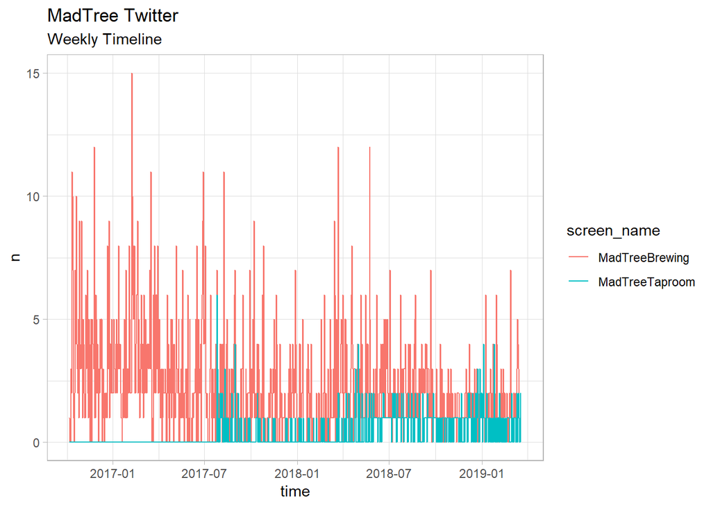

```r
m_ts <- Madtree_tweets %>%
  filter(created_at > "2016-1-01") %>%
  group_by(screen_name) %>%
  ts_plot(,"weeks", trim = 1L) +
  labs(title = "MadTree Twitter",
       subtitle = "Weekly Timeline") +
  theme_light()
m_ts
```

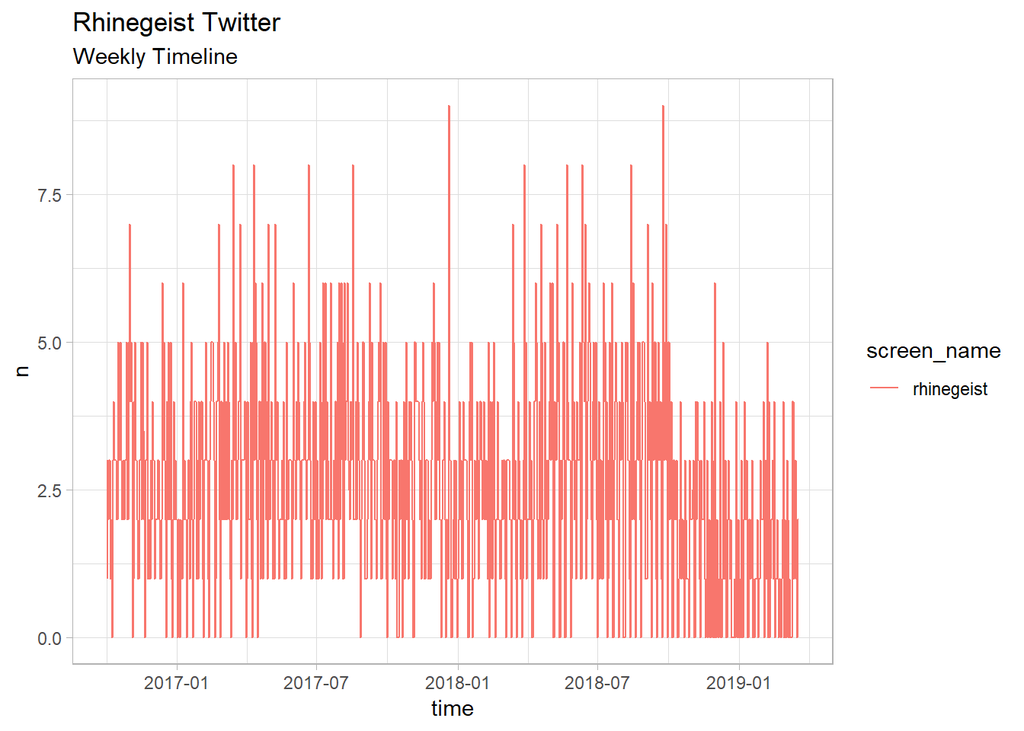

```r
r_ts <- Rhinegeist_tweets %>%
  filter(created_at > "2016-1-01") %>%
  group_by(screen_name) %>%
  ts_plot(,"weeks", trim = 1L) +
  labs(title = "Rhinegeist Twitter",
       subtitle = "Weekly Timeline") +
  theme_light()
r_ts
```

Text analysis Data Prep for Madtree. Remove any http from twitter text

```r
Madtree_tweets$stripped_text <- gsub("http.*","",  Madtree_tweets$text)
Madtree_tweets$stripped_text <- gsub("https.*","", Madtree_tweets$stripped_text)
head(Madtree_tweets$stripped_text)
```

```
## [1] "Sure, the name on the can is Shade but when you're a ride or die fan you call it ShadÃ©. #themoreyouknow #tapin #MadTree "
## [2] "@kellbel89 Sorry, they sold out in a couple hours yesterday"
## [3] "Weâ\200\231re heading to Indy this Saturday for Sour Wild Funk Fest at @UplandBrewCo!  The fest will feature over 50 of the worldâ\200\231s best sour producers pouring rare beers. Tickets are going fast! Get yours here → "
## [4] "All green everything today. #inspiringmadness #rootedinpurpose #MadTree "
## [5] "Rounding Third red IPA blends grapefruit hop aromas and caramel malts to create a robust beer that can stand up to Spring ball's yo-yo weather. Remember - beer needs baseball and baseball needs MadTree. #inspiringmadness #rootedinpurpose #MadTree "
## [6] "When being an adult is awesome: Bourbon Barrel Aged S'more Gratitude. We took the flavors of your favorite campfire dessert and aged it in a bourbon barrel for a balanced yet decadent treat. A limited amount of bottles go on sale Monday at 11AM in the taproom. Limit 2 btls/person "
```

Get stop works to remove redudant words. Stop words include words such as the, an, a, and those.They are typically general words which lead to more specific words. We want ot find the specific words to see how MadTree makes their customer interactions and marketing strategies unique on Twitter. After we unnest tokens to identify words used across their tweets, we remove any stop words.

```r
data("stop_words")

Madtree_tidytext <- Madtree_tweets %>%
  select(stripped_text) %>%
  unnest_tokens(word, stripped_text) %>%
  anti_join(stop_words)
nrow(Madtree_tidytext)
```

```
## [1] 21565
```

Graph Madtree unique word counts. From this graph, we can see that MadTree typically uses words associated with a brewery such as drink, cans, and beers. They also use a few words that are unique to its brand in Cincinnati such as their taproom, and drinktrees. The most unique wowrd is the emoji of beer glasses clanking each other. I thnik this Twitter activity is what you would expect from a brewery but there is not enought unique words used to sell people on their unique aspects. Many people from the Cincinnati area will tell you they go to Madtree for the community aspect of it especially for their garden which is open to all ages and allows people to bring their pets. These qualities are unique to Madtree between these two breweries, and I do not believe they are utilizing it well enough from looking at their Twitter feed.

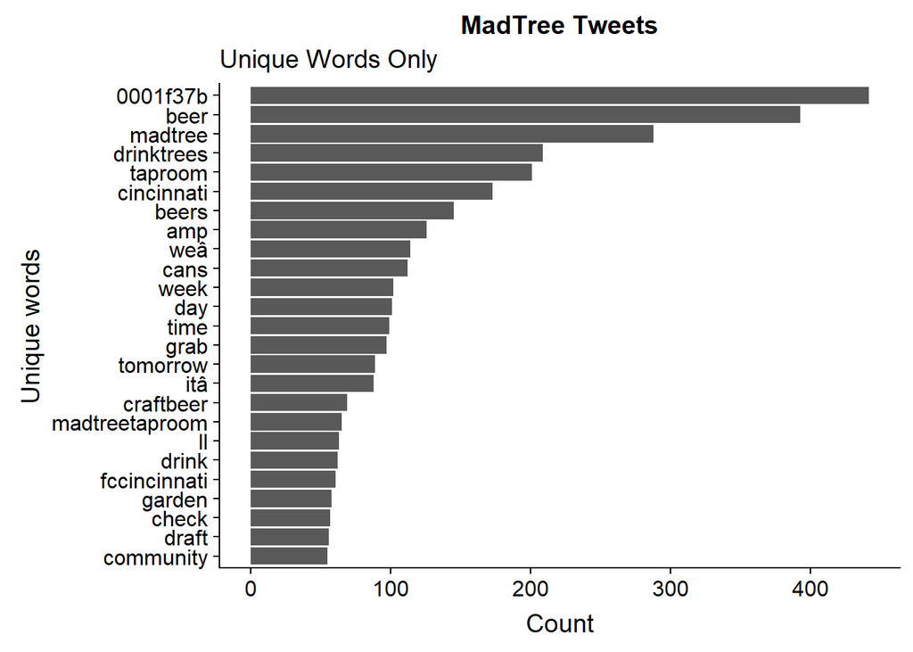

```r
munique <- Madtree_tidytext %>%
  count(word, sort = TRUE) %>%
  top_n(25) %>%
  mutate(word = reorder(word, n)) %>%
  ggplot(aes(x = word, y = n)) +
  geom_col() +
  xlab(NULL) +
  coord_flip() +
  labs(y = "Count",
       x = "Unique words",
       title = "MadTree Tweets",
       subtitle = "Unique Words Only")
munique
```

Text analysis Data Prep for Rhingeist. Remove any http from twitter text

```r
Rhinegeist_tweets$stripped_text <- gsub("http.*","",  Rhinegeist_tweets$text)
Rhinegeist_tweets$stripped_text <- gsub("https.*","", Rhinegeist_tweets$stripped_text)
head(Rhinegeist_tweets$stripped_text)
```

```
## [1] "Sip for a cause!\nCharitable Suds returns to the taproom tonight from 5-8pm, benefitting Inner City Youth Opportunities!\n\nYou can also stick around for Wednesday night trivia with @lastcalltrivia â\200sign ups at 7, questions at 7:30. "
## [2] "Now pouring: SG-036 (3.34%) Gose with Strawberry &amp; Lime\nLight and tart with a punch of fruit flavor- freshly kegged from our Spring Grove innovation brewing system. "
## [3] "@PghBlue16 Coming to Pittsburgh in a few weeks!"
## [4] "@_CMcGarry_ not yet- but hopefully one day!"
## [5] "Rainbow Reverie.\nBeta Guppy, our new Hazy IPA, glides through waves of peach, orange &amp; melon. Pillowy, aromatic &amp; Ã¼ber juicy.\nCanning tomorrow, available in the taproom this Friday at 3pm (limit 2 4-pks/person).\nComing to taps and shelves this weekend.\nABV: 7% "
## [6] "@victoriaheart1D stay tuned for the release!"
```

```r
Rhinegeist_tidytext <- Rhinegeist_tweets %>%
  select(stripped_text) %>%
  unnest_tokens(word, stripped_text) %>%
  anti_join(stop_words)
nrow(Rhinegeist_tidytext)
```

```
## [1] 33232
```

Graph of Rhinegeist unique words used on Twitter. Rhinegeist seems to be more event focused as they seem to have a more unified social media presence. With key words such as fb “Facebook”, event, and specific time references. Rhingeist seems to better distinguish it’s brand on social media as it shows it shows they are more event focused.

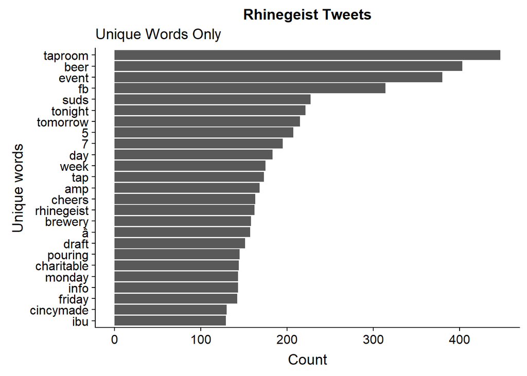

```r
runique <- Rhinegeist_tidytext %>%
  count(word, sort = TRUE) %>%
  top_n(25) %>%
  mutate(word = reorder(word, n)) %>%
  ggplot(aes(x = word, y = n)) +
  geom_col() +
  xlab(NULL) +
  coord_flip() +
  labs(y = "Count",
       x = "Unique words",
       title = "Rhinegeist Tweets",
       subtitle = "Unique Words Only")
runique
```

Word sort by count to identify which words used most commonly indicate which emotion MadTree uses in tweets.

```r
Madtree_counts <- Madtree_tidytext %>%
  count(word, sort = TRUE)
Madtree_counts
```

```
## # A tibble: 5,861 x 2
##    word           n
##    <chr>      <int>
##  1 0001f37b     442
##  2 beer         393
##  3 madtree      288
##  4 drinktrees   209
##  5 taproom      201
##  6 cincinnati   173
##  7 beers        145
##  8 amp          126
##  9 weâ          114
## 10 cans         112
## # ... with 5,851 more rows
```

Sentiment analysis preparation. Bing assigns a value that usually indicates what emotion a certain word conveys. This value is being assigned to words MadTree used most frequently in tweets

```r
bing <- get_sentiments("bing")

Madtree_counts <- Madtree_counts %>%
  inner_join(bing)
nrow(Madtree_counts)
```

```
## [1] 441
```

Plot the sentiment value of most common words for Madtree twitter data. THis graph is slightly wrong as the context for some of the negative words are positive in this situation such as limited time beer, ice cold beer, and hang with friends. All the positive sentiment words are great, but it’s very similar to Rhingeist and shows that they are struggling to set their online presence apart from Rhinegeist.

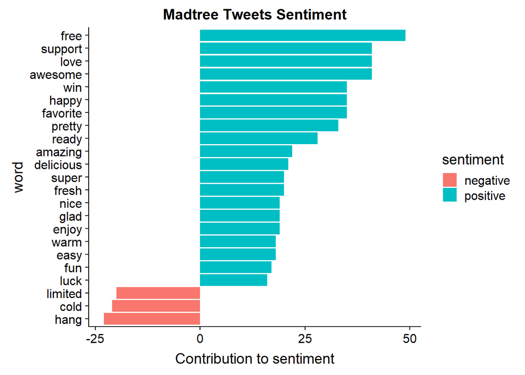

```r
m_sent <- Madtree_counts %>%
  filter(n > 15) %>%
  mutate(n = ifelse(sentiment == "negative", -n, n)) %>%
  mutate(word = reorder(word, n)) %>%
  ggplot(aes(word, n, fill = sentiment)) +
  geom_col() +
  coord_flip() +
  labs(y = "Contribution to sentiment",
       title = "Madtree Tweets Sentiment")
m_sent
```

Word sort by count to identify which words used most commonly indicate which emotion Rhingeist uses in tweets.

```r
Rhinegeist_counts <- Rhinegeist_tidytext %>%
  count(word, sort = TRUE)
Rhinegeist_counts
```

```
## # A tibble: 6,283 x 2
##    word         n
##    <chr>    <int>
##  1 taproom    447
##  2 beer       403
##  3 event      380
##  4 fb         314
##  5 suds       227
##  6 tonight    221
##  7 tomorrow   215
##  8 5          207
##  9 7          195
## 10 day        183
## # ... with 6,273 more rows
```

```r
Rhinegeist_counts <- Rhinegeist_counts %>%
  inner_join(bing)
nrow(Rhinegeist_counts)
```

```
## [1] 447
```

Plot the sentiment for Rhinegeist.Rhingeist sentiment analysis is very similar to MadTree’s. Each revolves around creating a theme for their brewery with words like awesome, happy, and free. They also have words that are not really negative in the context used. For example, the majority of the negative sentiment words such as wild, hazy, sour dark, and pale all describe their brand and the beer. From Rhingeist’s sentiment analysis, it seems like they describe their brews more compared to MadTree.

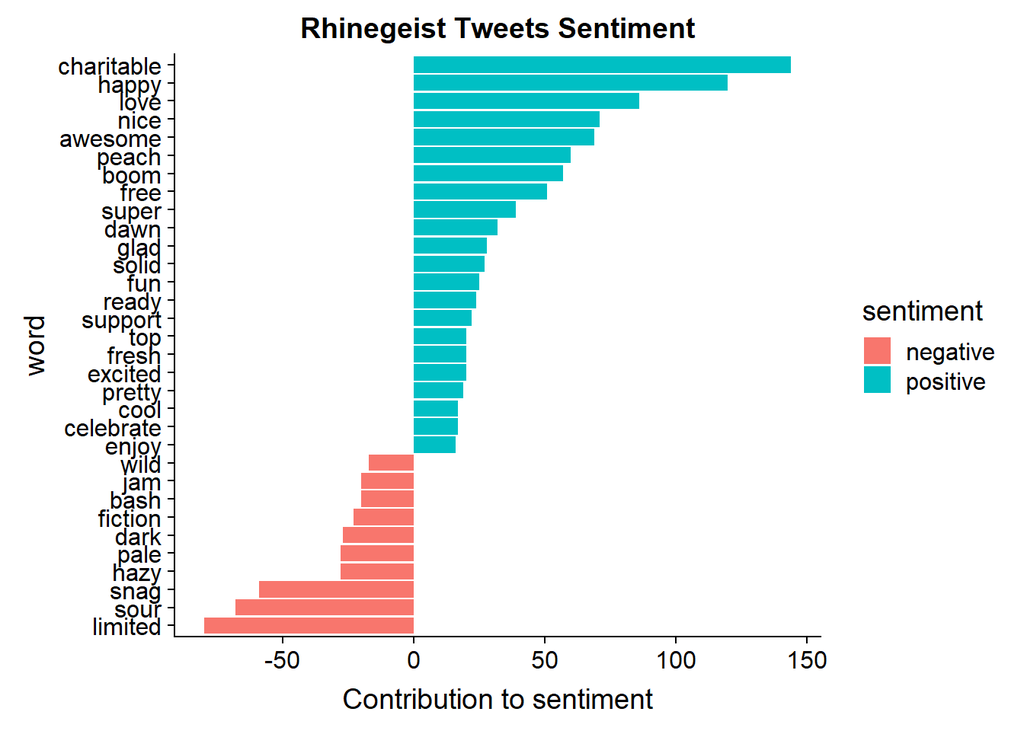

```r
r_sent <- Rhinegeist_counts %>%
  filter(n > 15) %>%
  mutate(n = ifelse(sentiment == "negative", -n, n)) %>%
  mutate(word = reorder(word, n)) %>%
  ggplot(aes(word, n, fill = sentiment)) +
  geom_col() +
  coord_flip() +
  labs(y = "Contribution to sentiment",
       title = "Rhinegeist Tweets Sentiment")
r_sent
```

## Conclusion:

If we look at these plots side-by-side it is much more clear to draw conclusions.

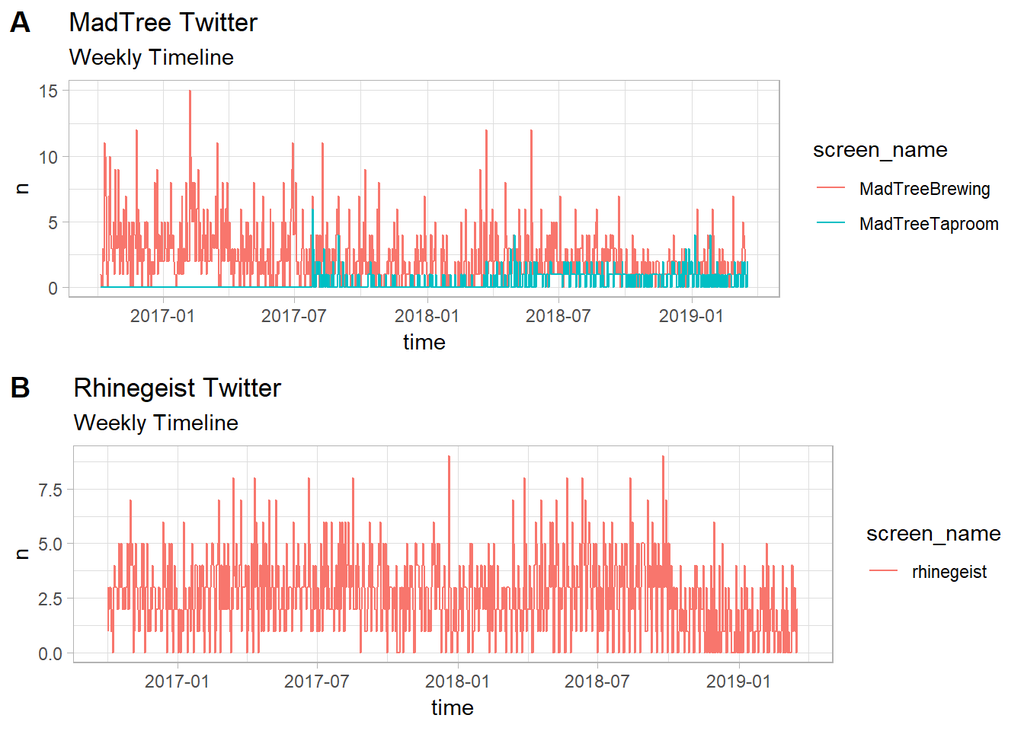

```r
plot_grid(m_ts, r_ts, labels = "AUTO", nrow = 2)
```

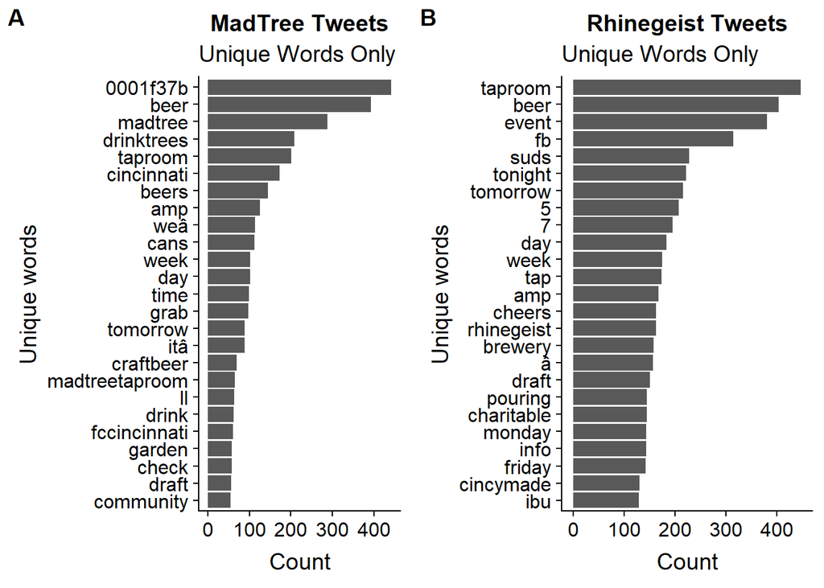

```r
plot_grid(munique, runique, labels = "AUTO", ncol = 2)
```

I think the unique word plot is where the differences really show. I think MadTree needs to better leverage it’s community aspect. That is a key portion of their success is the garden where you can drink beers with friends and family, but it is hard to read that from this graph. Like I previously mentioned, they market more to families encouraging them to bring their kids or their dogs. The fun for the whole family is really the core of their appeal, but they are struggling to promote that on Twitter. Rhingeist has a much more concrete and unified approach to using Twitter. They seem to be much more event focused and coordinated between social media platforms as they invite followers on Twitter to checkout their facebook events.

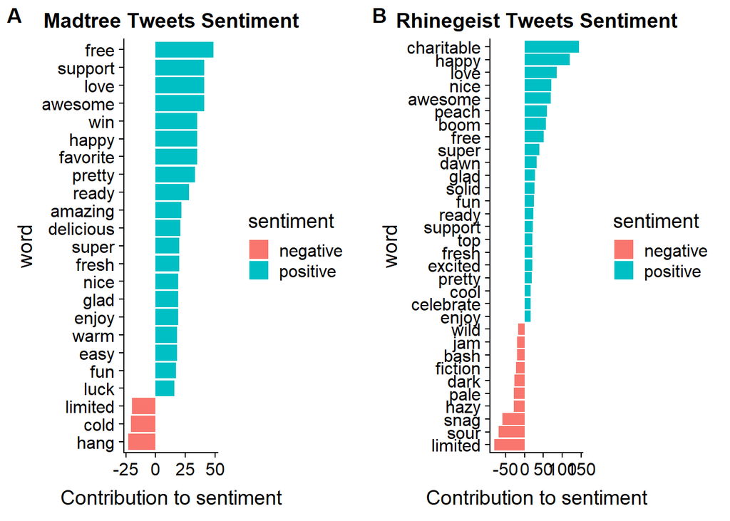

```r
plot_grid(m_sent, r_sent, labels = "AUTO", ncol = 2)
```

The sentiment analysis does not prove much in how each brewery markets themself on Twitter. They use very similar words to invite people to come to events and enjoy the weekend at their brewery frequently and the negative words are actually positive in this context. The key distinction in the sentiment analyiss is that Rhinegeist is more descriptive of the brand itself using key words to illustrate it’s gothic aesthetic.

## Final Thoughts:

I think MadTree does not do enough to distinguish itself from another popular brewery Rhinegeist. I think it has a very family friendly vibe which is one of the key strengths that they are not leveraging with their online presence. Rhinegeist does a better job of differentiating itself from MadTree as it adopts a event-oriented approach to Twitter. They are also more descriptive of the brand and product itself. They utilize the unique gothic tone of the brand to better market themselves on Twitter compared to MadTree.